# LinearModelsPart2

Steve Elston

03/06/2021

# Review

Linear models are a flexible and widely used class of models

- Fit model coefficients by **least squares** estimation
- Can use many types of predictor variables
- We prefer the simplest model that does a reasonable job
  - The principle of **Occam’s razor**
- Must consider the **bias-variance trade-off**

# Review

When evaluating any machine learning model consider **all evaluation methods available**

- No one method best all of the time
  - Homoskedastic Normally distributed residuals
  - Reasonable values $R^2$, RMSE, etc
  - Are the model coefficients all significant?
- **Different methods highlight different problems** with your model
- Don’t forget to check that the **model must make sense** for your application!

# Review

Representation of machine learning models

- The key representation is the model matrix
  - Column of 1s for intercept
  - Columns of feature or predictor values

$$A =
\begin{bmatrix}
1, x_{1,1}, x_{1,2}, \ldots, x_{1,p}\\
1, x_{2,1}, x_{2,2}, \ldots, x_{2,p}\\
1, x_{3,1}, x_{3,2}, \ldots, x_{3,p}\\
\vdots,\ \vdots,\ \vdots,\ \vdots,\ \vdots\\
1, x_{n,1}, x_{n,2}, \ldots, x_{n,p}
\end{bmatrix}$$

- There are two standards for signatures of ML functions
  - A model matrix $X$ (exogenous-features) and label array $Y$ (dependent-endogenous) - Scikit-learn and base Statsmodels
  - A data frame with all features (predictors) and label (dependent) columns plus a model formula - Statsmodels formula and R

# Review

There are a number of assumptions in linear models that you overlook at your peril!

- The feature or predictor variables should be **independent** of one another
  - This is rarely true in practice
  - **Multi-collinearity** between features makes the model **under-determined**
- We assume that numeric features or predictors have **zero mean** and about the **same scale**
  - We do not want to bias the estimation of regression coefficients with predictors that do not have a 0 mean
  - We do not want to have predictors with a large numeric range dominate training
  - Example: income is in the range of 10s or 100s of thousands and age is in the range of 10s, but apriori income is no more important than age as a predictor
- Values of each predictor or feature should be iid
  - If variance changes with sample, the optimal value of the coefficient could not be constant
  - If there **serial correlation** in the predictor values, the iid assumption is violated - but can account for this such as in time series models

# Review

Scaling of features is required for many machine learning models

- Several commonly used approaches
  - **Z-score** scaling results in features with zero mean and unit variance
  - Use Z-score scaling for features approximately normally distributed
  - **Min-max** scaling transforms feature values to range 0-1
  - Use min-max scaling for features with truncated range of values
- Effect on model coefficients
  - Scaling changes model coefficients by the scale factor applied
  - Can re-scale (unscale) model coefficients before processing unknown cases
  - Or use **same scaling** for unknown feature values
- When coding categorical variables as binary dummy variables no need to scale - already in range [0-1]

# Introduction

- Working with categorical variables
  - One-hot encoding
- Over-fit models and regularization
  - Bias variance trade-off
  - L2 regularization
  - L1 regularization
  - Elastic Net

# Working with Categorical Variables

Linear models, like nearly all machine learning models, use numeric features

- How can categorical variables be used in linear models?
- Need to transform categories to numeric variables with **one hot encoding**
  - Each category becomes a binary **dummy variable**, encoded [0,1]
  - Only one dummy variable has nonzero value - encodes the category
  - n categories represented by n-1 dummy variables; all 0s encodes one level
- Binary variables are an exception
  - Represent with a single binary variable. [0,1] values

# Working with Categorical Variables

Example: Consider a data set with categorical variables

```
##     id  female  race  ses  schtyp  prog  read  write  math  science  socst
## 0   70       0     4    1       1     1    57     52    41       47     57
## 1  121       1     4    2       1     3    68     59    53       63     61
## 2   86       0     4    3       1     1    44     33    54       58     31
## 3  141       0     4    3       1     3    63     44    47       53     56
## 4  172       0     4    2       1     2    47     52    57       53     61
## 5  113       0     4    2       1     2    44     52    51       63     61
## 6   50       0     3    2       1     1    50     59    42       53     61
## 7   11       0     1    2       1     2    34     46    45       39     36
## 8   84       0     4    2       1     1    63     57    54       58     51
## 9   48       0     3    2       1     2    57     55    52       50     51
```

# Working with Categorical Variables

Example: split the data into train and test subsets

```python
nr.seed(2345)
msk = nr.choice(test_scores.index, size = 120, replace=False)
test_scores_train = test_scores.iloc[msk,:]
print(test_scores_train.shape)
```

```
## (120, 11)
```

```python
test_scores_test = test_scores.drop(msk, axis=0)
print(test_scores_test.shape)
```

```
## (80, 11)
```

# Working with Categorical Variables

Example: We can encode a categorical variable with the Python patsy package to get the X (model) and Y(label) arrays:

```python
from patsy import dmatrices
Y, X = dmatrices("socst ~ C(ses, levels=[1,2,3])", data=test_scores)
print(X[:5])
```

```
## [[1. 0. 0.]
##  [1. 1. 0.]
##  [1. 0. 1.]
##  [1. 0. 1.]
##  [1. 1. 0.]]
```

```python
print(Y[:5])
```

```
## [[57.]
##  [61.]
##  [31.]
##  [56.]
##  [61.]]
```

# Working with Categorical Variables

Example: A simple linear model with one categorical variable

```python
import statsmodels.formula.api as smf
linear_model = smf.ols("socst ~ C(ses)", data=test_scores_train).fit()
linear_model.summary()
```

```
## <class 'statsmodels.iolib.summary.Summary'>
## """
##                             OLS Regression Results
## ==============================================================================
## Dep. Variable:                  socst   R-squared:                       0.097
## Model:                            OLS   Adj. R-squared:                  0.082
## Method:                 Least Squares   F-statistic:                     6.285
## Date:                Wed, 07 Apr 2021   Prob (F-statistic):            0.00255
## Time:                        19:48:50   Log-Likelihood:                -446.60
## No. Observations:                 120   AIC:                             899.2
## Df Residuals:                     117   BIC:                             907.6
## Df Model:                           2
## Covariance Type:            nonrobust
## ===============================================================================
##                   coef    std err          t      P>|t|      [0.025      0.975]
## -------------------------------------------------------------------------------
## Intercept      47.5926      1.949     24.415      0.000      43.732      51.453
## C(ses)[T.2]     4.8635      2.366      2.055      0.042       0.177       9.550
## C(ses)[T.3]     9.1296      2.579      3.540      0.001       4.023      14.237
## ==============================================================================
## Omnibus:                        3.392   Durbin-Watson:                   2.023
## Prob(Omnibus):                  0.183   Jarque-Bera (JB):                3.413
## Skew:                          -0.397   Prob(JB):                        0.182
## Kurtosis:                       2.772   Cond. No.                         4.53
## ==============================================================================
##
## Notes:
## [1] Standard Errors assume that the covariance matrix of the errors is correctly specified.
## """
```

# Working with Categorical Variables

Wait! What happened to the coefficient for the first level of ses?

- The intercept is the **mean response** of the first level
- The other coefficients are **contrasted** with respect to the mean of the first level.
- Consider the following possible ways we can encode responses to a categorical variable - often called a **treatment**
  - For $n$ treatments, there are mean responses $[ \mu_1, \mu_2, \ldots, \mu_n ]$
  - The alternative encoding is a treatment with intercept, $I$, at $n - 1$ contrasts, $[ I, c_1, \ldots, c_{n-1}$
- The means and contrasts are related:

$$\begin{bmatrix}
I\\
c_2\\
\vdots\\
c_n
\end{bmatrix} =
\begin{bmatrix}
\mu_1\\
\mu_2 - I\\
\vdots\\
\mu_n - I
\end{bmatrix}$$

# Working with Categorical Variables

In a linear model we can sometimes relate the coefficient values to an effect size

- Start with $n$ treatments $[t_1, t_2, \ldots, t_n ]$ with effect sizes, $[e_1, e_2, \ldots, e_n ]$
- With **no intercept term** the means represent the effect sizes:

$$\begin{bmatrix}
e_1\\
e_2\\
\vdots\\
e_n
\end{bmatrix} =
\begin{bmatrix}
\mu_1\\
\mu_2\\
\vdots\\
\mu_n
\end{bmatrix}$$

- With intercept term compute effect sizes using contrasts:

$$\begin{bmatrix}
e_1\\
e_2\\
\vdots\\
e_n
\end{bmatrix} =
\begin{bmatrix}
I\\
I + c_1\\
\vdots\\
I + c_{n-1}
\end{bmatrix}$$

# Working with Categorical Variables

In a linear model we can sometimes relate the coefficient values to an effect size

- Assumes the treatments are orthogonal
  - In other words, applied on at a time
  - e.g. a case can only be in one category
- Assumes that the model coefficients are statistically independent
  - Coefficients are dependent in overfit model
- Often need to **adjust** for other effects
  - Other treatments
  - Levels of other categorical variables
  - Use **partial slope** of continuous variables
- In other words **apply** with care!
  - Don’t over-interpret your model
  - Conditions in real world hard to verify, particularly for observational data

# Dealing with Overfit Models

Example: We might suspect that the terms, ses and prog are significant in predicting social science test scores:

```python
linear_model = smf.ols("socst ~ C(ses)*C(prog)", data=test_scores_train).fit()
linear_model.summary()
```

```
## <class 'statsmodels.iolib.summary.Summary'>
## """
##                             OLS Regression Results
## ==============================================================================
## Dep. Variable:                  socst   R-squared:                       0.372
## Model:                            OLS   Adj. R-squared:                  0.326
## Method:                 Least Squares   F-statistic:                     8.204
## Date:                Wed, 07 Apr 2021   Prob (F-statistic):           1.13e-08
## Time:                        19:48:50   Log-Likelihood:                -424.85
## No. Observations:                 120   AIC:                             867.7
## Df Residuals:                     111   BIC:                             892.8
## Df Model:                           8
## Covariance Type:            nonrobust
## ============================================================================================
##                                coef    std err          t      P>|t|      [0.025      0.975]
## --------------------------------------------------------------------------------------------
## Intercept                   45.8000      2.743     16.695      0.000      40.364      51.236
## C(ses)[T.2]                  5.2625      3.497      1.505      0.135      -1.667      12.192
## C(ses)[T.3]                  8.8000      4.752      1.852      0.067      -0.616      18.216
## C(prog)[T.2]                12.2000      3.880      3.145      0.002       4.512      19.888
## C(prog)[T.3]               -10.5143      4.275     -2.459      0.015     -18.986      -2.043
## C(ses)[T.2]:C(prog)[T.2]    -6.0352      4.814     -1.254      0.213     -15.575       3.504
## C(ses)[T.3]:C(prog)[T.2]    -7.8769      5.744     -1.371      0.173     -19.260       3.506
## C(ses)[T.2]:C(prog)[T.3]     7.5570      5.191      1.456      0.148      -2.728      17.843
## C(ses)[T.3]:C(prog)[T.3]     3.3143      6.956      0.476      0.635     -10.469      17.097
## ==============================================================================
## Omnibus:                        3.386   Durbin-Watson:                   2.085
## Prob(Omnibus):                  0.184   Jarque-Bera (JB):                2.985
## Skew:                          -0.382   Prob(JB):                        0.225
## Kurtosis:                       3.119   Cond. No.                         18.4
## ==============================================================================
##
## Notes:
## [1] Standard Errors assume that the covariance matrix of the errors is correctly specified.
## """
```

# Dealing with Overfit Models

Example: After 3 or 4 rounds of *guess and cut* feature pruning, we arrive at a model with only significant coefficients:

```python
linear_model = smf.ols("socst ~ - 1 + C(ses):C(prog)", data=test_scores_train).fit()
linear_model.summary()
```

```
## <class 'statsmodels.iolib.summary.Summary'>
## """
##                             OLS Regression Results
## ==============================================================================
## Dep. Variable:                  socst   R-squared:                       0.372
## Model:                            OLS   Adj. R-squared:                  0.326
## Method:                 Least Squares   F-statistic:                     8.204
## Date:                Wed, 07 Apr 2021   Prob (F-statistic):           1.13e-08
## Time:                        19:48:50   Log-Likelihood:                -424.85
## No. Observations:                 120   AIC:                             867.7
## Df Residuals:                     111   BIC:                             892.8
## Df Model:                           8
## Covariance Type:            nonrobust
## ========================================================================================
##                            coef    std err          t      P>|t|      [0.025      0.975]
## ----------------------------------------------------------------------------------------
## C(ses)[1]:C(prog)[1]    45.8000      2.743     16.695      0.000      40.364      51.236
## C(ses)[2]:C(prog)[1]    51.0625      2.169     23.544      0.000      46.765      55.360
## C(ses)[3]:C(prog)[1]    54.6000      3.880     14.073      0.000      46.912      62.288
## C(ses)[1]:C(prog)[2]    58.0000      2.743     21.142      0.000      52.564      63.436
## C(ses)[2]:C(prog)[2]    57.2273      1.850     30.941      0.000      53.562      60.892
## C(ses)[3]:C(prog)[2]    58.9231      1.701     34.633      0.000      55.552      62.294
## C(ses)[1]:C(prog)[3]    35.2857      3.279     10.761      0.000      28.788      41.783
## C(ses)[2]:C(prog)[3]    48.1053      1.990     24.171      0.000      44.161      52.049
## C(ses)[3]:C(prog)[3]    47.4000      3.880     12.217      0.000      39.712      55.088
## ==============================================================================
## Omnibus:                        3.386   Durbin-Watson:                   2.085
## Prob(Omnibus):                  0.184   Jarque-Bera (JB):                2.985
## Skew:                          -0.382   Prob(JB):                        0.225
## Kurtosis:                       3.119   Cond. No.                         2.28
## ==============================================================================
##
## Notes:
## [1] Standard Errors assume that the covariance matrix of the errors is correctly specified.
## """
```

# Dealing with Overfit Models

Let’s compare the results of the unpruned and pruned models

- The metrics indicate the fit is exactly the same
  - Why prefer the pruned model?
- What are the consequences of the over-fit model?
  - Several predictors (features) are included that are not needed
  - Including non-significant predictors can only reduce generalization of the model
  - Consider the effect of an unexpected value of a non-significant predictor on the response recalling the response is linear in the coefficients
- But manually pruning a model with a great many features is a doomed task!
  - What if we included all the interactions with type of school, race and sex?
  - We now have up to 5th order interaction - 45 model coefficients with none significant!!

# Dealing with Overfit Models

**Idea!:** Try systematically pruning the model using some metric

- But hard to find a good metric
- Further, making multiple hypothesis tests is a fraught undertaking
  - High probability of Type 1 or Type 2 error
  - The multiple hypothesis problem
- Leads to the the **step-wise regression algorithm**
  - Forward step-wise regression adds most explanatory variable one at a time
  - Backward step-wise regression removes lest explanatory variable one at a time
  - Can go both directions - see the R documentation

# Regularization - a Better Approach

Regularization is a systematic approach to preventing over-fitting

- To understand regularization need to understand the bias-variance trade-off
- To better understand this trade-off decompose mean square error:

$$\Delta y = E \big[ Y - \hat{f}(X) \big]$$
$y =$ the label vector
$X =$ the feature matrix
$\hat{f}(x) =$ the trained model

- Expanding this relation gives us:

$$\Delta y = \big( E[ \hat{f}(X)] - \hat{f}(X) \big)^2 + E \big[ ( \hat{f}(X) - E[ \hat{f}(X)])^2 \big] + \sigma^2\\
\Delta y = Bias^2 + Variance + Irreducible\ Error$$

# Regularization - a Better Approach

There is a trade-off between bias and variance

- Need to find the trade-off point

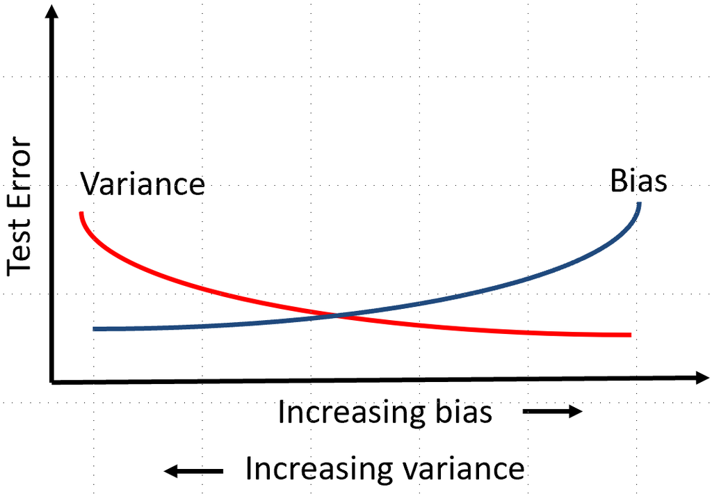

The trade-off between bias and variance

# Regularization - a Better Approach

Decompose the $p$ x $p$ covariance matrix $cov(A) = \frac{1}{p}A^TA$ into **eigenvalues** and **eigenvectors**:

$$cov(A) = Q \Lambda Q^{-1}$$

where,

$Q$ is the $p$ x $p$ matrix of $p$ **orthonormal eigenvectors** of length $p$

And, the $p$ eigenvalues are represented as diagonal matrix:

$$\Lambda =
\begin{bmatrix}
\lambda_1, 0, \ldots, 0\\
0, \lambda_2, \ldots \\
\vdots,\ \vdots,\ \vdots,\ \vdots\\
0, 0, \ldots, \lambda_p
\end{bmatrix}$$

For real-valued $cov(A)$ the eigenvectors $Q$ are real valued so:

$$Q^{-1} = Q^T$$

# Regularization - a Better Approach

The inverse of the covariance can be computed from its eigendecomposition

$$cov(A)^{-1} = Q^T \Lambda^{-1} Q$$

Where $Q^{-1}$ is written:

$$\Lambda^{-1} =
\begin{bmatrix}
\frac{1}{\lambda_1}, 0, \ldots, 0\\
0, \frac{1}{\lambda_2}, \ldots \\
\vdots,\ \vdots,\ \vdots,\ \vdots\\
0, 0, \ldots, \frac{1}{\lambda_p}
\end{bmatrix}$$

# Regularization - a Better Approach

At first look eigen-decomposition seems a bit mysterious

- The eigenvalues are the **roots** of the covariance matrix
  - Similar to the familiar roots of a polynomial
- For square matrix, $A$, and some norm 1 vector, $x$, we can find a root, $\lambda$:

$$\begin{align}
Ax &= \lambda x \\
Ax - \lambda x &= 0 \\
(A - I \lambda) x &= 0
\end{align}$$

- For $n$ x $n$ dimensional matrix there are $n$ eigenvalues and orthogonal eigenvalue
- But, there is no guarantee that the $n$ values of $\lambda$ are unique
  - If columns of $A$ are colinear, there are $< n$ unique eigenvectors

# Regularization - a Better Approach

If columns of $A$ are not linearly independent, the covariance matrix is **ill-posed** and the eigenvectors are under-determined

$$cov(A) = Q \Lambda Q^T\\
cov(A)^{-1} = Q^T \Lambda^{-1} Q$$

- The eigenvalues are ordered, $\lambda_1 \ge \lambda_2 \ge \ldots \ge \lambda_p$
- For ill-posed covariance matrix
  - The smallest $\lambda_i \rightarrow 0$
  - So, $\frac{1}{\lambda_i} \rightarrow \infty$
  - The inverse covariance matrix does not exist!

# L2 Regularization

L2 regularization constrains the Euclidean norm of the parameter vector, $\vec{b}$

- Recall:

$$x = A b + \epsilon$$

- The **normal equations provide a solution**:

$$b = (A^TA)^{-1}A^Tx$$

- This solution requires finding the inverse of the covariance matrix, $(A^TA)^{-1}$
  - But this inverse may be unstable
  - In mathematical terminology we say the problem is **ill-posed**

# L2 Regularization

L2 regularization constrains the Euclidean norm of the parameter vector, $\vec{b}$

- We can add a **bias term** to the diagonal of the covariance matrix

the **L2 or Euclidean norm** minimization problem):

$$min [\parallel A \cdot x - b \parallel +\ \alpha \parallel b\parallel]\\ or \\
b = (A^TA + \alpha^2 I)^{-1}A^Tx$$

Where the L2 norm of the coefficient vector is:
$$||b|| = \big( \beta_1^2 + \beta_2^2 + \ldots + \beta_m^2 \big)^{\frac{1}{2}} = \Big( \sum_{i=1}^m \beta_i^2 \Big)^{\frac{1}{2}}$$

# L2 Regularization

How can we understand this relationship?

$$b = (A^TA + \alpha^2I)^{-1}A^Tx$$

- Adds values along the diagonal of the covariance matrix
  - This creates a so called ridge in the covariance, $cov_{regularized} = A^TA + \alpha^2$
  - Leads to the term **ridge regression**
- Constrain the L2 norm values of the model coefficients using the **penalty term** $\alpha$
  - Larger $\alpha$ is more bias but lover variance
  - Larger $\alpha$ makes the inverse of the covariance more stable
- L2 regularization is a **soft constraint** on the model coefficients
  - Even smallest coefficients are not driven to 0
  - All coefficients can grow in value, but under the constraint

# L2 Regularization

Eigen-decomposition of the regularized covariance matrix:

$$A^TA + \alpha^2I = Q
\begin{bmatrix}
\lambda_1 + \alpha^2, 0, \ldots, 0\\
0, \lambda_2 + \alpha^2, \ldots \\
\vdots,\ \vdots,\ \vdots,\ \vdots\\
0, 0, \ldots, \lambda_p + \alpha^2
\end{bmatrix}
Q^T$$

The inverse covariance matrix is then:

$$\Big( A^TA + \alpha^2I \Big)^{-1} = Q^T
\begin{bmatrix}
\frac{1}{\lambda_1 + \alpha^2}, 0, \ldots, 0\\
0, \frac{1}{\lambda_2 + \alpha^2}, \ldots \\
\vdots,\ \vdots,\ \vdots,\ \vdots\\
0, 0, \ldots, \frac{1}{\lambda_p + \alpha^2}
\end{bmatrix}
Q$$

With any $\alpha > 0$, the inverse eigenvalues of the inverse covariance matrix are bounded

Increasing $\alpha$ increases bias, but increases the stability of the inverse

# L2 Regularization

**Example:** compute the eigenvalues of a covariance matrix

```python
test_scores['socst_zero_mean'] = test_scores['socst'] - np.mean(test_scores['socst'])
Y, X = dmatrices("socst_zero_mean ~ C(ses, levels=[1,2,3])*C(prog, levels=[1,2,3])", data=test_scores)
cov_X = np.matmul(np.transpose(X),X)
cov_X = np.divide(cov_X, float(cov_X.shape[0]))
np.real(np.linalg.eigvals(cov_X))
```

```
## array([41.33783544, 13.34471885,  8.85600018,  2.37491505,  1.7218998 ,
##         1.6220889 ,  0.11774255,  0.38848204,  0.45853941])
```

**Add regularization** with $\alpha=0.1$ and compute the eigenvalues

```python
alpha_sqr = 0.1
alpha_sqr = np.diag([alpha_sqr] * cov_X.shape[0])
#alpha_sqr = np.diag([alpha] * cov_X.shape[0])
#cov_X = np.divide(np.matmul(np.transpose(X),X), float(cov_X.shape[0]))
cov_X = np.add(cov_X, alpha_sqr)
np.real(np.linalg.eigvals(cov_X))
```

```
## array([41.43783544, 13.44471885,  8.95600018,  2.47491505,  1.8218998 ,
##         1.7220889 ,  0.21774255,  0.48848204,  0.55853941])
```

# L2 Regularization

L2 regularization constrains the Euclidean norm of the parameter vector, $\vec{b}$

- The norm of the coefficient vector, $\vec{b}$, is constrained

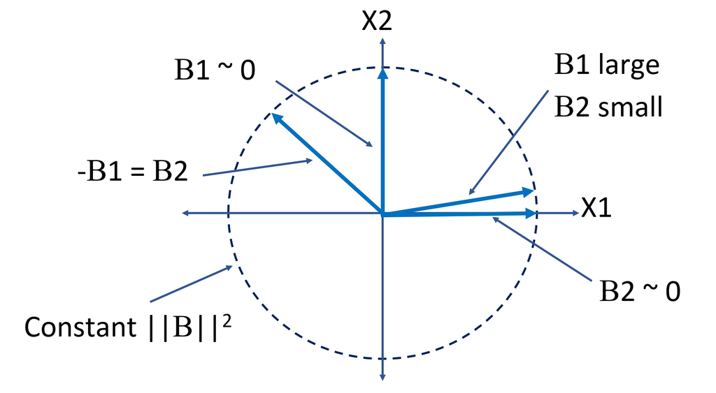

L2 norm constraint of model coefficients

# L2 Regularization

Example: Increasing constraint on model coefficients with larger L2 regularization hyperparameter

```python
def regularized_coefs(df_train, df_test, alphas, L1_wt=0.0, n_coefs=8,
                      formula = 'socst_zero_mean ~ C(ses)*C(prog)',
                      label='socst_zero_mean'):
    '''Function that computes a linear model for each value of the regularization
    parameter alpha and returns an array of the coefficient values. The L1_wt
    determines the trade-off between L1 and L2 regularization'''
    coefs = np.zeros((len(alphas),n_coefs + 1))
    MSE_train = []
    MSE_test = []
    for i,alpha in enumerate(alphas):
        ## First compute the training MSE
        temp_mod = smf.ols(formula, data=df_train).fit_regularized(alpha=alpha,L1_wt=L1_wt)
        coefs[i,:] = temp_mod.params
        MSE_train.append(np.mean(np.square(df_train[label] - temp_mod.predict(df_train))))
        ## Then compute the test MSE
        MSE_test.append(np.mean(np.square(df_test[label] - temp_mod.predict(df_test))))

    return coefs, MSE_train, MSE_test

alphas = np.arange(0.0, 0.3, step = 0.003)
Betas, MSE_test, MSE_train = regularized_coefs(test_scores_train, test_scores_test, alphas)
#Betas[:5]
```

# L2 Regularization

Example: Increasing constraint on model coefficients with larger L2 regularization hyperparameter

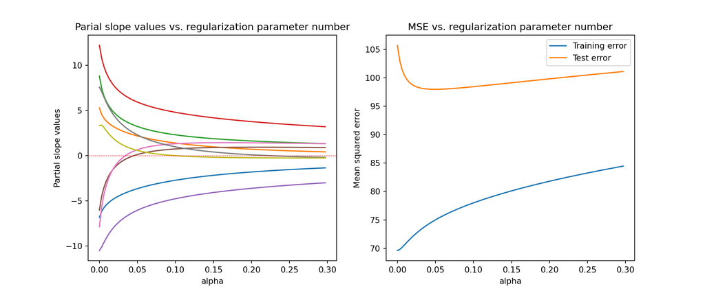

# L1 Regularization

The L1 norm provides regularization with different properties

- Constrains the model parameters using the L1 norm:

$$min [\parallel A \cdot x - b \parallel +\ \alpha \parallel b\parallel^1]$$

- This form looks a lot like the L2 regularization formulation
- $\parallel b\parallel^1$ is the L1 norm
- Compute the l1 norm of the $m$ model parameters:

$$||b||^1 = \big( |b_1| + |b_2| + \ldots + |b_m| \big) = \Big( \sum_{i=1}^m |b_i| \Big)^1$$

$|b_i|$ is the absolute value of $b_i$.

# L1 Regularization

What are the properties of the L1 regularization

- L1 norm is a **hard constraint**
- L1 regularization drives coefficients to zero
- The hard constraint property leads to the term **lasso regularization**
- Lasso regression is a method of **feature selection**

# L1 Regularization

The Lasso regularization is a strong constraint on coefficient values

- Some coefficients are forced to zero
- The constraint curve is like a *lasso*

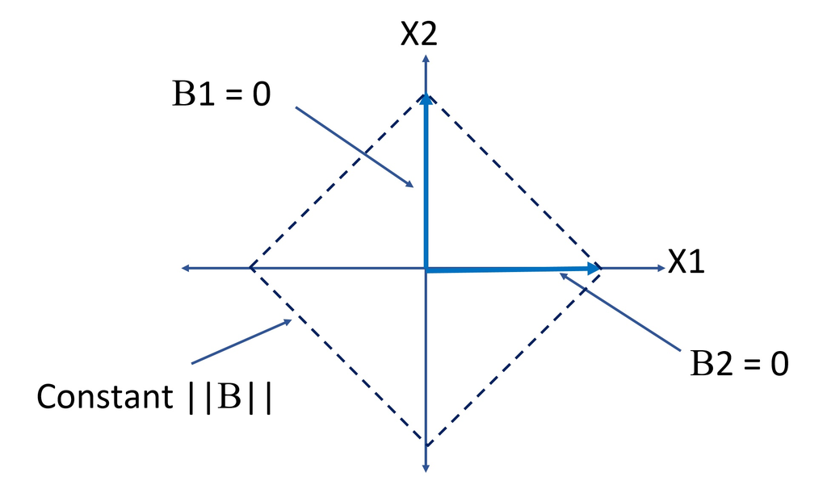

L1 norm constraint of model coefficients

# L1 Regularization

Example: Increasing constraint on model coefficients with larger L1 regularization hyperparameter

```python
alphas = np.arange(0.0, 0.5, step = 0.005)
Betas, MSE_train, MSE_test = regularized_coefs(test_scores_train, test_scores_test, alphas, L1_wt=1.0)
Betas[:5]
```

```
## array([[ -6.52032993,   4.9411634 ,   8.48005864,  11.78120324,
##         -10.90012816,  -5.61643065,  -7.45952169,   7.94289118,
##           3.69873278],
##        [ -6.36621595,   4.74954943,   8.20598715,  11.4549758 ,
##         -10.79194046,  -5.22543049,  -6.99025982,   7.84062452,
##           3.5905026 ],
##        [ -6.21210196,   4.55793546,   7.93191565,  11.12874835,
##         -10.68375277,  -4.83443034,  -6.52099794,   7.73835787,
##           3.48227242],
##        [ -6.05798797,   4.36632149,   7.65784415,  10.80252091,
##         -10.57556508,  -4.44343019,  -6.05173607,   7.63609121,
##           3.37404223],
##        [ -5.90387399,   4.17470752,   7.38377266,  10.47629347,
##         -10.46737739,  -4.05243004,  -5.58247419,   7.53382455,
##           3.26581205]])
```

# L1 Regularization

Example: Increasing constraint on model coefficients with larger L1 regularization hyperparameter

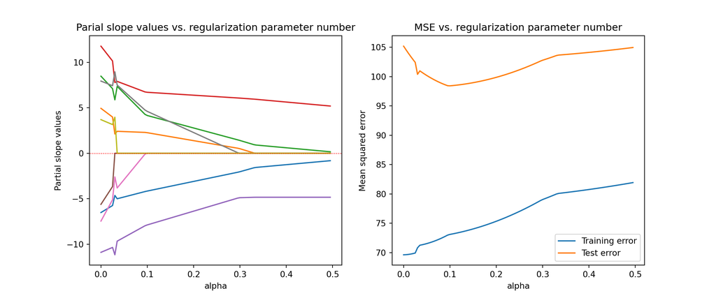

# Elastic Net Regularization

Do we always have to choose between the soft constraint of L2 and the hard constraint of L1?

- L2 regularization works well for **colinear features**
  - Down-weights colinear features
  - But soft constraint so poor model selection
- L1 regularization provides **good model selection** by hard constraint
  - But poor selection for colinear features
- The **Elastic Net** weights L1 and L2 regularization
  - Hyperparameter $\lambda$ weights L1 vs. L2 regularization
  - Hyperparameter $\alpha$ sets strength of regularization

$$min \Big[ \parallel A \cdot x - b \parallel +\ \lambda\ \alpha \parallel b\parallel^1 +\ (1- \lambda)\ \alpha \parallel b\parallel^2 \Big]$$

# Elastic Net Regularization

Example: Increasing constraint on model coefficients with larger L1 regularization hyperparameter

```python
alphas = np.arange(0.0, 0.5, step = 0.005)
Betas, MSE_train, MSE_test = regularized_coefs(test_scores_train, test_scores_test, alphas, L1_wt=0.5)
Betas[:5]
```

```
## array([[ -6.52032993,   4.9411634 ,   8.48005864,  11.78120324,
##         -10.90012816,  -5.61643065,  -7.45952169,   7.94289118,
##           3.69873278],
##        [ -6.09717074,   4.46954704,   7.42768669,  10.70679116,
##         -10.25742267,  -4.41965698,  -5.67883339,   7.21887121,
##           3.42003779],
##        [ -5.7386268 ,   4.0861054 ,   6.63809671,   9.84624619,
##          -9.70719072,  -3.4857793 ,  -4.34105083,   6.58381956,
##           3.07683405],
##        [ -5.43817824,   3.77473882,   6.02896287,   9.15448442,
##          -9.22410068,  -2.75195008,  -3.31451036,   6.01867313,
##           2.72173676],
##        [ -5.1837706 ,   3.51714742,   5.54329116,   8.59060693,
##          -8.7962148 ,  -2.16570298,  -2.50686206,   5.51496312,
##           2.38308676]])
```

# Elastic Net Regularization

Example: Increasing constraint on model coefficients with larger L1 regularization hyperparameter

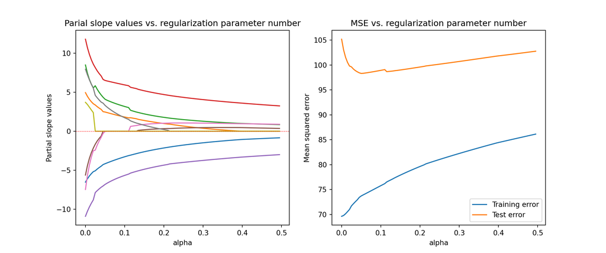

# Elastic Net Regularization

Check the model summary for $\lambda=0.5$, $\alpha=0.06$

```python
lm_elastic = smf.ols("socst_zero_mean ~ C(ses)*C(prog)", data=test_scores_train).fit_regularized(alpha=0.06, L1_wt=0.5)
lm_elastic.params
```

```
## Intercept                  -3.966399
## C(ses)[T.2]                 2.319184
## C(ses)[T.3]                 3.861480
## C(prog)[T.2]                6.376850
## C(prog)[T.3]               -6.524469
## C(ses)[T.2]:C(prog)[T.2]    0.000000
## C(ses)[T.3]:C(prog)[T.2]    0.000000
## C(ses)[T.2]:C(prog)[T.3]    2.896917
## C(ses)[T.3]:C(prog)[T.3]    0.000000
## dtype: float64
```

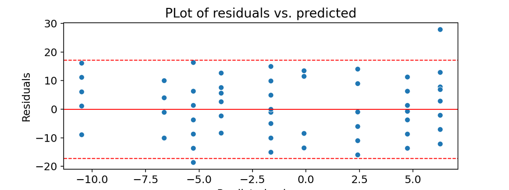

# Summary